# Week Two

## Permutation Test

## Example: Final grades

Do students with an even # of letters in their last name perform differently, on average, than those with an even # of letters in their last name?

i.e. the **parameter** of interest is \(\mu_E - \mu_O\)

We propose the following model:

\[H_0: \mu_E - \mu_O = 0\] But we will technically conduct the test with a more specific model:

\[ H_0: F_E = F_0 \]

## Intro Stats Final Exam

**Beware**: the solid line is the median, not the mean.

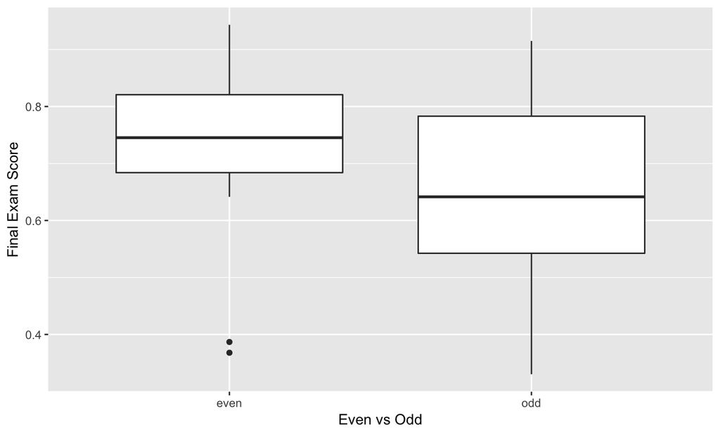

## Permutation Test

To describe the permutation test, we now consider

- only the first 6 rows
- and for illustrative purposes a new variable `row_index`

## Intro Stats Final Exam

| final | even_vs_odd | row_index |
| --- | --- | --- |
| 0.915 | odd | 1 |
| 0.811 | even | 2 |
| 0.906 | even | 3 |
| 0.943 | even | 4 |
| 0.877 | odd | 5 |
| 0.840 | even | 6 |

## Observed Test Statistic

Rows `c(2, 3, 4, 6)` are the students with an even # of letters in their last name.

To compute the **observed test statisitic** i.e. the observed difference in sample means \(\overline{x}_E - \overline{x}_O\) we run

```r
index <- c(2, 3, 4, 6)

# mean of evens - mean of odds:
mean(grades$final[grades$even == "even"]) - mean(grades$final[grades$even == "odd"])

# or
grades %>%
  group_by(even) %>%
  summarize(xbar = mean(final)) %>%
  summarize(diff(xbar))
```

## Observed Data

Originally, the evens are `c(2, 3, 4, 6)`

| final | even_vs_odd | row_index |
| --- | --- | --- |
| 0.915 | odd | 1 |
| 0.811 | even | 2 |
| 0.906 | even | 3 |
| 0.943 | even | 4 |
| 0.877 | odd | 5 |
| 0.840 | even | 6 |

## Permuted Data

| final | even_vs_odd | row_index |
| --- | --- | --- |
| 0.915 | odd | 1 |
| 0.811 | even | 2 |
| 0.906 | even | 3 |
| 0.943 | even | 4 |
| 0.877 | even | 5 |
| 0.840 | odd | 6 |

## Permuted Data

| final | even_vs_odd | row_index |
| --- | --- | --- |
| 0.915 | even | 1 |
| 0.811 | odd | 2 |
| 0.906 | odd | 3 |
| 0.943 | even | 4 |
| 0.877 | even | 5 |
| 0.840 | even | 6 |

## Permuted Data

| final | even_vs_odd | row_index |
| --- | --- | --- |
| 0.915 | even | 1 |
| 0.811 | even | 2 |
| 0.906 | odd | 3 |
| 0.943 | even | 4 |
| 0.877 | odd | 5 |
| 0.840 | even | 6 |

## Permuted Data

| final | even_vs_odd | row_index |
| --- | --- | --- |
| 0.915 | odd | 1 |
| 0.811 | even | 2 |
| 0.906 | odd | 3 |
| 0.943 | even | 4 |
| 0.877 | even | 5 |
| 0.840 | even | 6 |

## Coding the Permutation

The permuting/shuffling of the `even_vs_odd` label is done by by taking a random sample of size \(n\) from that column without replacement.

```r
head(grades$even)
```

```
## [1] "odd"  "even" "even" "even" "odd"  "even"
```

```r
permuted_even <- sample(grades$even, replace = FALSE)
head(permuted_even)
```

```
## [1] "even" "even" "odd"  "odd"  "odd"  "even"
```

## Activity

Read the grade data in with the following:

```r
grades <- read.csv("http://bit.ly/2Fry1lV")
```

1. Implement the permutation test, plot the null distribution, and estimate the p-value.
2. Conduct a similar hypothesis test, but this time set \(T(x) = m_{even} - m_{odd}\). Is the p-value approximately the same?

## Permutation test 1

Test statistic: \(\bar{x}_{even} - \bar{x}_{odd}\)

```r
it <- 5000
xbar1_xbar2 <- rep(NA, it)

for (i in 1:it) {
  perm_even <- sample(grades$even, replace = FALSE)
  xbar1_xbar2[i] <- mean(grades$final[perm_even == "even"]) -
    mean(grades$final[perm_even == "odd"])
}
```

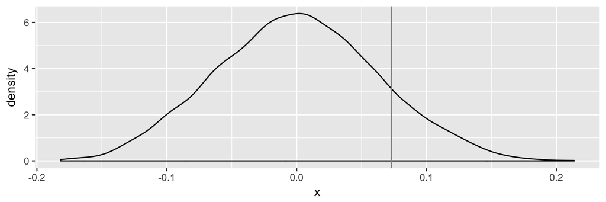

```r
obs_stat <- mean(grades$final[grades$even == "even"]) -
  mean(grades$final[grades$even == "odd"])
df <- data.frame(x = xbar1_xbar2)
ggplot(df, aes(x = x)) +
  geom_density() +
  geom_vline(xintercept = obs_stat, col = "tomato")
```

```r
mean(xbar1_xbar2 > obs_stat) * 2
```

```
## [1] 0.25
```

## Permutation test 2

Test statistic: \(m_{even} - m_{odd}\)

```r
it <- 5000
m1_m2 <- rep(NA, it)

for (i in 1:it) {
  perm_even <- sample(grades$even, replace = FALSE)
  m1_m2[i] <- median(grades$final[perm_even == "even"]) -
    median(grades$final[perm_even == "odd"])
}
```

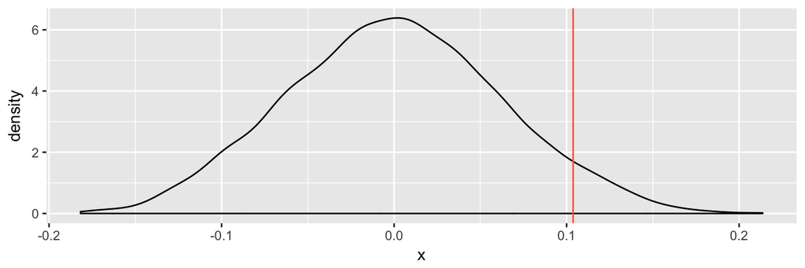

```r
obs_stat <- median(grades$final[grades$even == "even"]) -
  median(grades$final[grades$even == "odd"])
df <- data.frame(x = xbar1_xbar2)
ggplot(df, aes(x = x)) +
  geom_density() +
  geom_vline(xintercept = obs_stat, col = "tomato")
```

```r
mean(m1_m2 > obs_stat) * 2
```

```
## [1] 0.078
```

## Choice of statistic

## Means and medians compared

```r
it <- 5000
m1_m2 <- rep(NA, it)
xbar1_xbar2 <- rep(NA, it)

for (i in 1:it) {
  perm_even <- sample(grades$even, replace = FALSE)
  m1_m2[i] <- median(grades$final[perm_even == "even"]) -
    median(grades$final[perm_even == "odd"])
  xbar1_xbar2[i] <- mean(grades$final[perm_even == "even"]) -
    mean(grades$final[perm_even == "odd"])
}
```

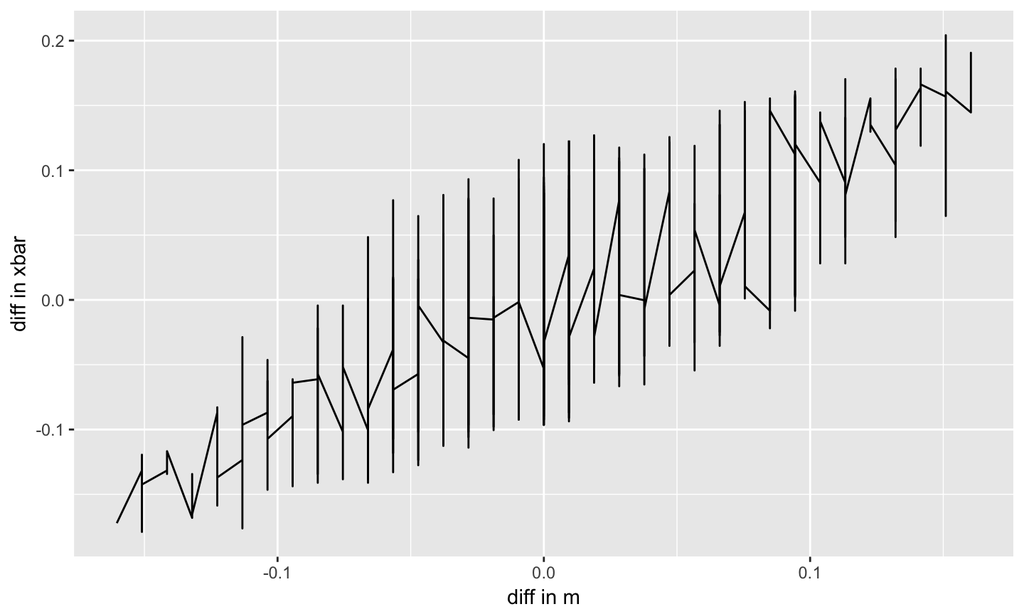

```r
df <- data.frame(x1 = m1_m2,
                 x2 = xbar1_xbar2)
ggplot(df, aes(x = x1, y = x2)) +
  geom_line() + xlab("diff in m") + ylab("diff in xbar")
```

…not a strictly increasing function.

## Means and medians compared

```r
it <- 5000
xbar1 <- rep(NA, it)
xbar1_xbar2 <- rep(NA, it)

for (i in 1:it) {
  perm_even <- sample(grades$even, replace = FALSE)
  xbar1[i] <- mean(grades$final[perm_even == "even"])
  xbar1_xbar2[i] <- mean(grades$final[perm_even == "even"]) -
    mean(grades$final[perm_even == "odd"])
}
```

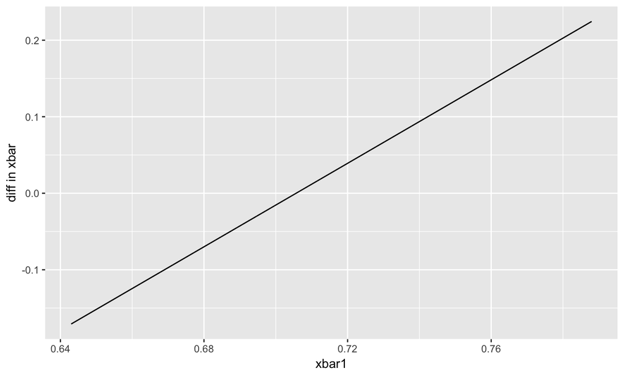

```r
df <- data.frame(x1 = xbar1,
                 x2 = xbar1_xbar2)
ggplot(df, aes(x = x1, y = x2)) +
  geom_line() + xlab("xbar1") + ylab("diff in xbar")
```

…now a strictly increasing function.

## Comparing p-values

```r
obs_stat_1 <- mean(grades$final[grades$even == "even"])
mean(xbar1 > obs_stat_1) * 2
```

```
## [1] 0.246
```

```r
obs_stat_2 <- mean(grades$final[grades$even == "even"]) -
    mean(grades$final[grades$even == "odd"])
mean(xbar1_xbar2 > obs_stat_2) * 2
```

```
## [1] 0.246
```

## Correcting p-values

In estimating the p-value in a non-exhaustive permutation test, it is safer to add one to the numerator and demoninator of your empirical fraction. That is, use

```r
(sum(xbar1_xbar2 > obs_stat) + 1)/(length(xbar1_xbar2) + 1) * 2
```

```
## [1] 0.0979804
```

instead of

```r
mean(xbar1_xbar2 > obs_stat) * 2
```

```
## [1] 0.0976
```

## Contingency Tables

## Finding a statistic

```r
(O <- table(bankstudy$gender, bankstudy$promote))
```

```
##
##          no yes
##   female 10  14
##   male    3  21
```

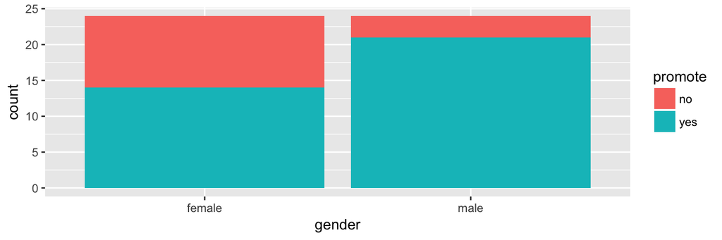

```r
ggplot(bankstudy, aes(x = gender, fill = promote)) +
  geom_bar()
```

## Expectation under \(H_0\)

If promotion is independent of gender, we can compute expected counts in each cell by

\[ E_{ij} = \frac{R_i C_j}{n} \]

```r
(E <- chisq.test(O)$expected)
```

```
##
##           no  yes
##   female 6.5 17.5
##   male   6.5 17.5
```

## Approach 1

We need to collapse these tables down to a single statistic. If we

- take the difference within each cell
- square the difference
- divide by the expected count
- add them up

we arrive at Pearson's \(\Chi^2\) statistic.

```r
obs_stat <- sum(((O - E)^2)/E)
obs_stat <- chisq.test(O, correct = FALSE)$stat
```

## Permutation chi-sq

```r
it <- 5000
chisqs <- rep(NA, it)

for (i in 1:it) {
  perm <- sample(bankstudy$gender, replace = FALSE)
  tab <- table(perm, bankstudy$promote)
  chisqs[i] <- chisq.test(tab, correct = FALSE)$stat
}
```

## Permutation chi-sq

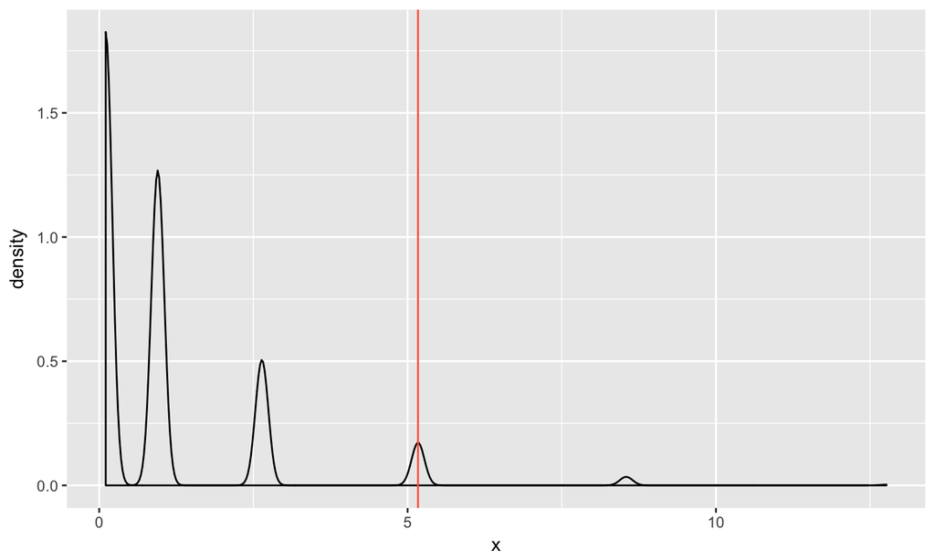

```r
df <- data.frame(x = chisqs)
ggplot(df, aes(x = x)) +
  geom_density() +
  geom_vline(xintercept = obs_stat, col = "tomato")
```

```r
mean(chisqs > obs_stat)
```

```
## [1] 0.0098
```